# Visualizing the human semantic network for animals in R

This page walks through the process of building and visualizing graphs (network data structures) in R, introducing some basic features of R along the way. It is also available as a JuPyteR notebook that you can download by clicking here. Graphs are useful structures for describing many different kinds of data. As an example domain, we will use graphs to visualize mental structures--specifically, the concepts and relations amongst various different animals that exist in your mind!

## Resources

**For new learners:** If you have never used R before, Swirl provides a nice tutorial introduction for using the software, from within the software itself. [find it here](https://swirlstats.com/)

**For a deeper dive:** Many R tutorials explain how to use the software for statistical analyses of data, but do not cover data science. The O'Reilly R for Data Science online resource provides a great, accessible introduction. [find it here](https://r4ds.had.co.nz/index.html)

**To learn about graphs:** This awesome tutorial provides a great overview of tools for working with graphs in R. [find it here](https://kateto.net/network-visualization)

**visNetwork documentation:** My favorite tool for visualizing graphs is visNetwork, which auto-generates Java script to produce beautiful, interactive visualizations that you can view in R or export for the Web. [find it here](https://datastorm-open.github.io/visNetwork/)

## Required packages

The tutorial requires the **igraph** and **visNetwork** packages. If you have them installed, just run the next block of code to load them into your workspace. If they are not installed, you need to perform a one-time installation using the [install.package](https://www.rdocumentation.org/packages/utils/versions/3.6.0/topics/install.packages) function.

```r
library(igraph) #Tools for building and visualizing graphs in R
library(visNetwork) #Tools for generating interactive visualizations of graphs in R
```

# Background

## What are graphs?

Graphs are data structures that describe networks. They are composed of two elements:

1. *nodes* (sometimes called *vertices*), with each node corresponding to some item
2. *edges* (sometimes called *links*), with each edge connecting two nodes, and representing some relationship between them. Edges can be *directed*--the relationship goes *from* node A *to* node B--or they can be *undirected*--A and B are linked, with no direction from one to the other.

For instance, consider the network that governs air travel acround the globe. We can view each airport as a node in that network, and each flight from one airport to another as a directed edge. We can represent the whole systems as a big, directed graph, and can use the graph for a variety of purposes--to find the shortest flight from one city to another, to figure out where to increase the frequency of flights, or to find geographic regions within which air-travel is easy or difficult.

Node and edges can possess *attributes* that describe their properties. Consider the attributes of airports: they vary in size, number of flights, the airlines they serve, the modernity of their facilities, etc. Likewise the flights between airports vary in their properties: how big the plane is, how expensive the ticket, which airline provides the flight, how fast the trip is, and so on. Each such attribute can be stored together with the corresponding node or edge in the graph structure. The attributes can then be used when plotting the graph to govern the size, shape, color, and so on, of the resulting nodes and edges.

[Read more about graphs here](https://medium.com/basecs/a-gentle-introduction-to-graph-theory-77969829ead8)

## Representing semantic knowledge as a graph

In cognitive science it is common to think of concepts in your mind as being related to one another in a *semantic network:* a kind of graph wher nodes correspond to individual concepts (like "table" or "dog" or "idea"), and edges correspond to links in memory between concepts. By "links in memory" I just mean that thinking of one concept automatically "brings to mind" some other concept. When I say cat, you may automatically think "dog." When I say "ice-cream," you might automatically think "cone" or "yummy" or "fattening." So one way of thinking about how knowledge is represented in your mind is as a graph structure containing the concepts you know as nodes, and as edges, the propensity for one concept to automatically activate another.

## The data

A common way to measure the nodes and links in some part of your "semantic network" is a simple task called *verbal fluency.* The participant is given a category name and asked to list all the examples of the category she can think of in whatever order they occur to her. If the category is "animal," the participant just lists all the animals she can think of. The list produced can be viewed as laying bare some of the nodes and edges in her graph. Suppose she begins with "dog." Thinking of dog will automatically bring another concept to mind--say "cat." So when dog precedes cat, we can infer there is a link in the semantic network that goes from dog to cat. Thinking of cat will bring another item to mind--say "bird"--revealing a link from cat to bird, and so on. Any one participant will only produce a small set of nodes and links, but if we gather together data from many participants, we might begin to get a broader picture of the nodes and links amongst animal concepts in a group semantic network.

For this tutorial, I asked people to spend 2 minutes typing out all the animals they could think of, and had them send me these lists as text files. There are 19 lists in the repository where this notebook is found. You will need them to complete the rest of this tutorial.

## Analysis

First let's read one list into a temporary object and look at it on the screen:

```r
tmp <- read.table("list1.txt", header=F, stringsAsFactors = F)
tmp
```

| V1 |
| --- |
| Elephant |
| Cat |
| Dog |
| Lizard |
| Frog |
| Cow |
| Pig |
| Chicken |
| Hen |
| Turtle |
| Goat |
| Sheep |
| Lamb |
| Bird |
| Giraffe |
| Penguin |
| Monkey |
| Hamster |
| Rat |
| Guinea-pig |
| Mouse |
| Hippo |
| Alligator |
| Crocodile |
| Flamingo |
| Snake |

Nice list! Some people capitalize their items, some don't--so let's convert everything to lower case so that Horse and horse don't get treated as separate items:

```r
tmp[,1] <- tolower(tmp[,1]) #tolower converts strings to all lower-case
tmp
```

| V1 |
| --- |
| elephant |
| cat |
| dog |
| lizard |
| frog |
| cow |
| pig |
| chicken |
| hen |
| turtle |
| goat |
| sheep |
| lamb |
| bird |
| giraffe |
| penguin |
| monkey |
| hamster |
| rat |
| guinea-pig |
| mouse |
| hippo |
| alligator |
| crocodile |
| flamingo |
| snake |

### Making a graph

We will use the **igraph** package loaded earlier to create a graph object. **igraph** takes a two-column dataframe as input, with the first column labeled "from" and the second column labeled "to." Each row describes a single edge in the graph by indicating the node where the edge originates (from) and the node where it terminates (to). This kind of dataframe is sometimes known as an *edge list* (even though it is not technically a list in R!). The data can be integers (like, from node 5 to node 10) or strings indicating the node names (like from "mouse" to "hippo"). In our case it is v useful to know the node names, since each node corresponds to a word produced in the fluency task.

So: from the list of words generated, we want to create an edge list. An edge in the graph indicates a link in memory between an item A and the next item B. In the data above, the first item that sprang to mind was "elephant"; producing "elephant" caused the next item ("cat") to come to mind--so in this participant, there is a mental link going from elephant to cat, which we want to represent as a directed edge in the graph. Likewise there is a link from cat to dog, dog to lizard, etc. So the "from" nodes include all of the items in the list except the last, and the "to" nodes include the 2nd item to the last item. We can generate the edge-list dataframe from the raw list like this:

```r
nitems <- dim(tmp)[1] #Total number of items stored in nitems
#Create the data frame with "from" and "to" fields containing the key data
#and store it in an object called list1
list1 <- data.frame(from=tmp[1:(nitems-1),1], to=tmp[2:nitems,1])
list1
```

| from | to |
| --- | --- |
| elephant | cat |
| cat | dog |
| dog | lizard |
| lizard | frog |
| frog | cow |
| cow | pig |
| pig | chicken |
| chicken | hen |
| hen | turtle |
| turtle | goat |
| goat | sheep |
| sheep | lamb |
| lamb | bird |
| bird | giraffe |
| giraffe | penguin |
| penguin | monkey |
| monkey | hamster |
| hamster | rat |
| rat | guinea-pig |
| guinea-pig | mouse |
| mouse | hippo |
| hippo | alligator |
| alligator | crocodile |
| crocodile | flamingo |
| flamingo | snake |

To creat a graph object from this edge-list dataframe, we use the corresponding igraph command:

```r
g1 <- graph_from_data_frame(list1) #Create graph from data frame and store it as g1
g1 #Dump the object to the screen so we can see it
```

```
IGRAPH 8b1ff95 DN-- 26 25 --
+ attr: name (v/c)
+ edges from 8b1ff95 (vertex names):
 [1] elephant  ->cat        cat       ->dog        dog       ->lizard
 [4] lizard    ->frog       frog      ->cow        cow       ->pig
 [7] pig       ->chicken    chicken   ->hen        hen       ->turtle
[10] turtle    ->goat       goat      ->sheep      sheep     ->lamb
[13] lamb      ->bird       bird      ->giraffe    giraffe   ->penguin
[16] penguin   ->monkey     monkey    ->hamster    hamster   ->rat
[19] rat       ->guinea-pig guinea-pig->mouse      mouse     ->hippo
[22] hippo     ->alligator  alligator ->crocodile  crocodile ->flamingo
+ ... omitted several edges
```

The above output tells us the object is an IGRAPH graph with 26 nodes and 25 edges, and lists several of the edges. We can plot this simple graph as follows:

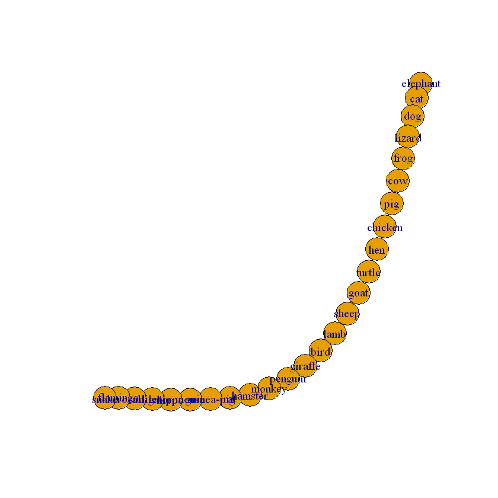

```r
plot(g1)
```

A more interesting graph will collapse the data across responses from *all* participants. We could iterate the steps above for each, but that is v time consuming. Instead let's write a function to do it for us:

```r
dget.edges <- function(fname){
    #Function to create an edge-list data frame from a verbal fluency list
    #fname: name of text file containing list of items produced, one item per line

    tmp <- read.table(fname, stringsAsFactors = F, sep="\n") #read the file to temporary object
    tmp[,1] <- tolower(tmp[,1]) #Make it all lower-case
    tmp[,1] <- gsub(" ","",tmp[,1]) #Remove any spaces in the names

    nitems <- dim(tmp)[1] #Total number of items produced

    o <- data.frame(from=tmp[1:(nitems-1),1], to=tmp[2:nitems,1]) #Make edge-list dataframe
    o #Return edge list dataframe
  }
```

**Tip:** If there are commands you don't understand in a function like this, just run help(command) in R, or Google it. For instance, what do you think the gsub function does? Try running help(gsub).

Now we can test the function on the same list we just analyzed to make sure it works:

```r
tmp <- dget.edges("list1.txt")
tmp
```

| from | to |
| --- | --- |
| elephant | cat |
| cat | dog |
| dog | lizard |
| lizard | frog |
| frog | cow |
| cow | pig |
| pig | chicken |
| chicken | hen |
| hen | turtle |
| turtle | goat |
| goat | sheep |
| sheep | lamb |
| lamb | bird |
| bird | giraffe |
| giraffe | penguin |
| penguin | monkey |
| monkey | hamster |
| hamster | rat |
| rat | guinea-pig |
| guinea-pig | mouse |
| mouse | hippo |
| hippo | alligator |
| alligator | crocodile |
| crocodile | flamingo |
| flamingo | snake |

Looks good! We can now use the dget.edges function we just created to read in edge lists for any subject, and can plot the results:

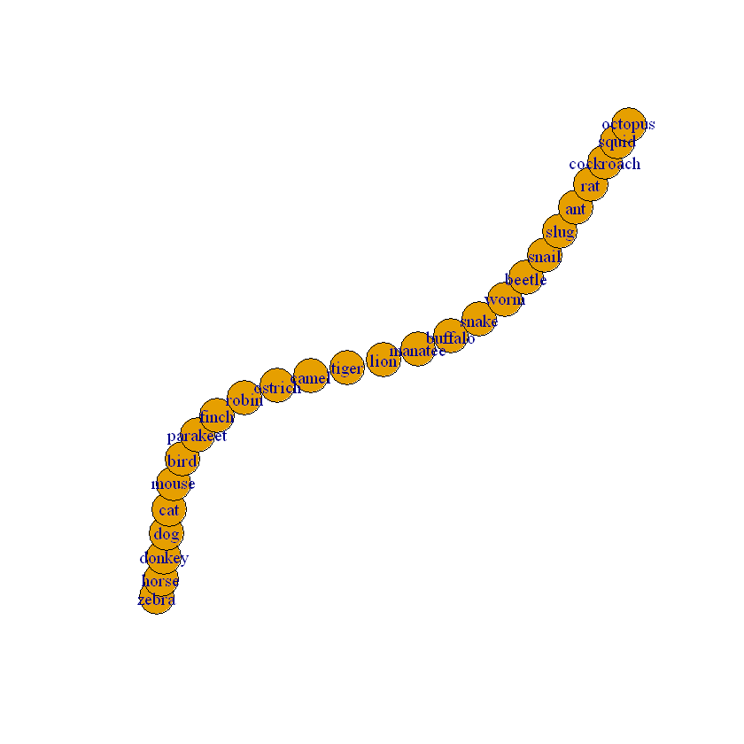

```r
tmp <- dget.edges("list10.txt")
gtmp <- graph_from_data_frame(tmp)
plot(gtmp)
```

**Tip:** I use tmp to indicate a temporary object in the R workspace. I always work with temporary objects until I feel comfortable that the analysis is working the way I want. Once I have something I want to keep, I typically rename the item to something more useful. That way I know I can always delete any objects named with tmp.

```r
rm(tmp, gtmp) #deletes these temporary objects from the workspace
```

What we really want to do is to read in the edgelists for each participant and glue them together to create one giant edgelist, describing a single graph compiled from all the subject responses. Let's start with just the first two lists:

```r
list1 <- dget.edges("list1.txt")
list2 <- dget.edges("list2.txt")
biglist <- rbind(list1, list2) #Bind the two lists together vertically
dim(biglist)
```

1. 55

2. 2

**rbind** takes two matrices or dataframes and binds them together vertically to return a single object. The new edgelist now has 55 entries, corresponding to 55 edges calculated from the two lists. Let's visualize the resulting graph:

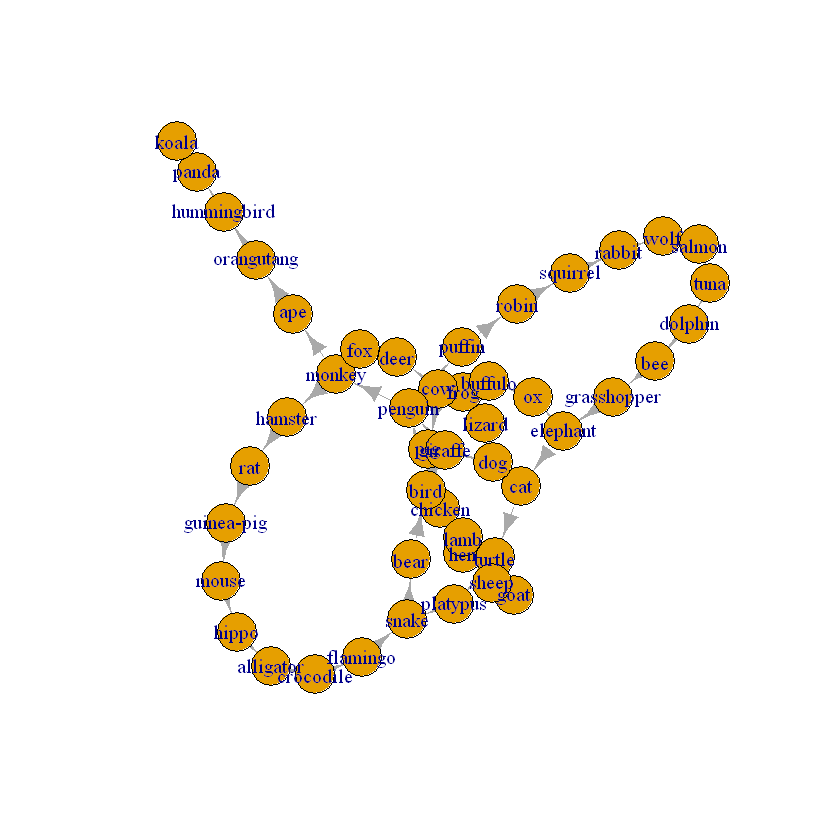

```r
g <- graph_from_data_frame(biglist)
plot(g)
```

More interesting! Several words appear in both lists, but followed by different items, so now there are some nodes with two edges. Again, we could manually add each participant's data in, but it would be more convenient to do this automatically.

```r
fnames <- list.files(pattern="*.txt") #Get the filenames for all text files in the current directory, store them in fnames
biglist <- dget.edges(fnames[1]) #Read the edgelist for the first textfile, store in biglist
nfiles <- length(fnames)  #How many files are there?

#Loop over all files after the first, read in the edgelist, and bind it to the biglist object
for(i in c(2:nfiles)) biglist <- rbind(biglist, dget.edges(fnames[i]))

dim(biglist)
```

1. 559

2. 2

In R, the **for** command initiates a loop in which a temporary variable (in this case *i*) takes on, in turn, each value in a specified vector, then carries out the following command. Here the variable *i* is iterating over a vector of integers ranging from 2 to the total number of files (nfiles). It first takes the value 2, then carries out the next command: binding together the current biglist and the file read in by dget.edges(fnames[i]). Since *i* currently equals 2, this will read in the second file in fnames, and bind it to the biglist object. Then *i* will iterate--it will take on the next value in the integer vector (3), and run the command again: reading in the third edgelist and binding it to the biglist object. Going all the way through the vector will successively add in each individual edgelist to the master edgelist. When the loop completes, all 559 edges across all lists will be stored in a single object.

```r
g <- graph_from_data_frame(biglist) #Make a graph from the edgelist

#Create an attribute field called "frq" for all the edges, indicating how often the edge appears
E(g)$frq <- 1
g
```

```
IGRAPH 07e3558 DN-- 198 559 --
+ attr: name (v/c), frq (e/n)
+ edges from 07e3558 (vertex names):
 [1] elephant  ->cat        cat       ->dog        dog       ->lizard
 [4] lizard    ->frog       frog      ->cow        cow       ->pig
 [7] pig       ->chicken    chicken   ->hen        hen       ->turtle
[10] turtle    ->goat       goat      ->sheep      sheep     ->lamb
[13] lamb      ->bird       bird      ->giraffe    giraffe   ->penguin
[16] penguin   ->monkey     monkey    ->hamster    hamster   ->rat
[19] rat       ->guinea-pig guinea-pig->mouse      mouse     ->hippo
[22] hippo     ->alligator  alligator ->crocodile  crocodile ->flamingo
+ ... omitted several edges
```

In **igraph**, you can specify the edges of the graph using the syntax E(name of graph object). Likewise you can specify just the vertices (nodes) using: V(name of graph). When nodes or edges have attributes, you can specify the attributes you want using the dollar-sign syntax. For instance V(g)$name will return the "name" attribute for all vertices in graph g. You can use the same syntax to create a new attribute for all vertices or nodes, by just creating a new name for the attribute and assigning it a value. In the above code, I created a new attribute for all edges called "frq" and assigned a value of 1 to this attribute for all edges.

So right now all edges have a frq attribute of 1---but don't forget, edges that are repeated multiple times across lists appear multiple times in the edge list. What we would like to do is to *simplify* the graph by collapsing all examples of a given edge to a single edge, and adding together the frq value across these instances. So if an edge appears 7 times in the master list, the simplified graph will replace those 7 edges with a single edge, but will give the frq attribute of the new edge a value of 7:

```r
g <- simplify(g, edge.attr.comb = "sum") #Combine edge duplicates by summing the values of their attributes
g
```

```
IGRAPH 0ebff07 DN-- 198 482 --
+ attr: name (v/c), frq (e/n)
+ edges from 0ebff07 (vertex names):
 [1] elephant->cat        elephant->giraffe    elephant->tiger
 [4] elephant->chimpanzee elephant->fish       elephant->polar_bear
 [7] elephant->ox         elephant->peacock    elephant->baboon
[10] cat     ->elephant   cat     ->dog        cat     ->pig
[13] cat     ->turtle     cat     ->bird       cat     ->mouse
[16] cat     ->horse      cat     ->parrot     cat     ->skunk
[19] dog     ->elephant   dog     ->cat        dog     ->lizard
[22] dog     ->pig        dog     ->lion       dog     ->ibex
+ ... omitted several edges
```

In the simplified graph, the number of edges has dropped from 559 to 482, and the frq attribute now indicates how often the edge appeared across all lists.

## Adding attributes to the nodes

There are some data about the items produced we probably want to compile and display in the graph. For instance, how often was each item produced across lists? Maybe we want more frequent items to appear as larger nodes in the plot. And, there are some data that we can get from the graph itself that we may want to display. For instance, how many edges are attached to each node (ie, what is the node degree)? Or we use the graph connectivity structure to group the nodes into clusters of items that are all densely interconnected with one another, and see if this grouping reveals anything about the mental structures that govern our semantic memory. Each of these pieces of data can be stored as an attribute with the nodes in the graph, and can then be used in visualization.

**igraph** provides tools for automatically computing certain properties of graphs. To calculated the node degree (number of edges attached to each node), use the degree function. There are a variety of algorithms for funding communities (clusters of densely connected nodes) in a graph--for directed graphs like this one, I like the spinglass algorithm.

```r
#To compute the degree of each node and store it as an attribute
V(g)$degree <- degree(g)

#To find communities in the graph using spinglass and store the results in a new object:
gcom <- spinglass.community(g)

#The new gcom objects has lots of information about communities.
#However the membership subfield is a vector that indicates
#to which community each node belongs. This can be stored as an attribute
V(g)$membership <- gcom$membership

#You can then use these attributes to set size and color data for the visualization:

nclust <- max(gcom$membership) #How many clusters were found?
V(g)$color <- rainbow(nclust)[gcom$membership] #Set the color of each node using rainbow colors
V(g)$size <- V(g)$degree  #Size the size of each node to show the node degree
```

I'll plot the results, but be warned, this is messy--we will get nicer visualizations further down.

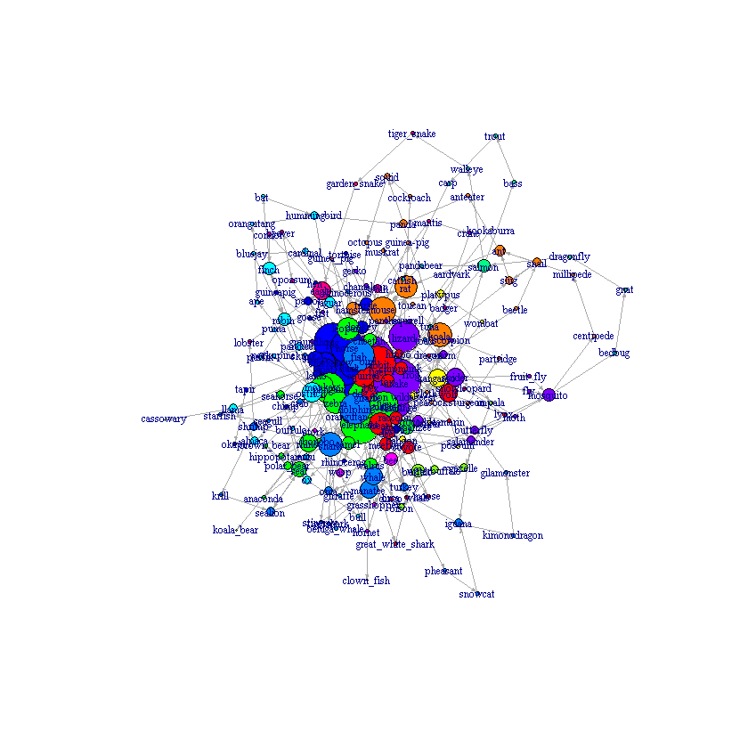

```r
plot(g, layout=layout_nicely, vertex.label.cex=.6, edge.arrow.size=.2)
```

Here each circle is an animal name. Circle size shows the node degree, and colors indicate the clusters of nodes (communities) discovered by spinglass. The output is kind of messy though. Perhaps we can simplify the graph further, by removing all the items that were only produced by a single person. To do that, we need to figure out how often each word appeared across all lists. Let's gather all the individual lists into a single master-list, then count how often each word appears in the master list, then store this number as a "frq" attribute for the corresponding node.

```r
tmp <- read.table(fnames[1], header = F, stringsAsFactors = F, sep="\n") #Read first list
nfiles <- length(fnames) #number of files

#loop to add all lists into a single object
for(i in c(2:nfiles)) tmp <- rbind(tmp, read.table(fnames[i], header = F, stringsAsFactors=F, sep="\n"))

tmp[,1] <- tolower(tmp[,1]) #lowercase everything
tmp[,1] <- gsub(" ","", tmp[,1]) #Remove spaces

V(g)$frq <- 0 #Create a field called frq for all nodes in the graph, initialize values to 0

nnodes <- length(V(g)$name) #Total number of nodes

#Loop through each node and count the number of items in tmp that match the node name, store as frq
for(i in c(1:nnodes)) V(g)$frq[i] <- sum(V(g)$name[i]==tmp[,1])
```

Now each node has an attribute called "frq" that indicates how often the word appeared across all lists, and another attribute called "degree" that indicates how many edges are connected to the node. We could look at the relationship between these:

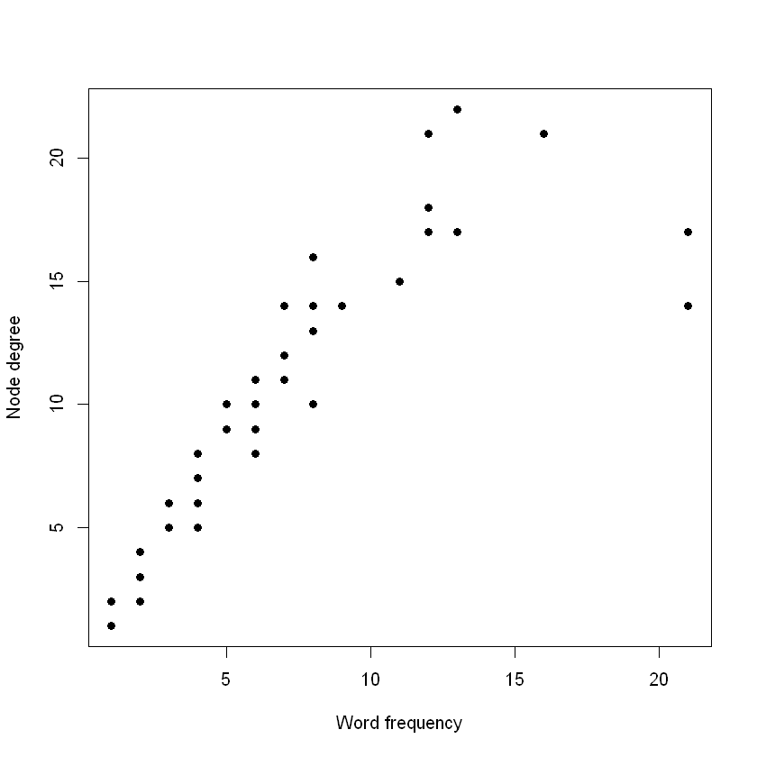

```r
plot(V(g)$frq, V(g)$degree, xlab="Word frequency", ylab="Node degree", pch=16)
```

Hey look, words that appeared more often also have more edges connected to them! Well I guess that is not too surprising.

Let's make the whole graph a bit simpler by removing all the nodes that were only listed by a single person. For the new graph, we can re-compute the communities, then plot again.

```r
#Make a smaller graph by removing nodes with freq one or less:
gsm <- delete_vertices(g, V(g)$frq <= 1)

#Compute communities for the smaller graph
gcomsm <- spinglass.community(gsm)

#How many communities did it find?
ncom <- max(gcomsm$membership)
```

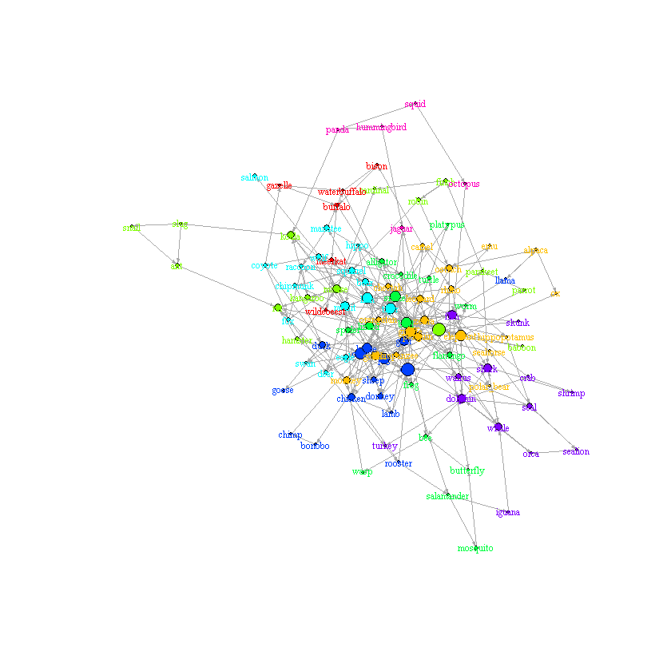

```r
#Set the color of each node and label using this number of rainbow colors
V(gsm)$color <- rainbow(ncom)[gcomsm$membership]
V(gsm)$label.color <- rainbow(ncom)[gcomsm$membership]

#Set the size of each node to reflect 2 x its log frequency
V(gsm)$size <- log(V(gsm)$frq) * 2

#Plot the result
plot(gsm, layout=layout_with_fr, vertex.label.cex=.6, edge.arrow.size=.2)
```

Now we are getting somewhere! We are beginning to see some interesting structure. For instance, many of the ocean animals make a community shown in the same color; four-legged exotic hoofed beasts make a community; and so on. Still, the graph is hard to see/understand. If only there was a better tool for visualization...

## Interactive visualization with visNetwork

There is! Specifically, the R package visNetwork, loaded earlier using library(visNetwork).

Whereas igraph contains all graph information in a single graph object, visNetwork interprets graph information from two different data frame objects: one containing a description of the nodes in the graph and their attributes, and the other containing a description of the attributes. Luckily, igraph and visNetwork play nicely together, and it is easy to generate one format from the other. To create a visNetwork-style description of the nodes and the edges from the igraph object we created, just do this:

```r
n <- as_data_frame(gsm, what="vertices") #Creates a dataframe from gsm describing the nodes/vertices, stores it as n
l <- as_data_frame(gsm, what="edges") #Creates a dataframe from gsm describing the edges/links, stores it as l
```

Let's look at the node data-frame

```r
head(n) #Head shows the first few rows of a data frame object
```

[output not shown]

All the information about the nodes from the igraph object is preserved! However, visNetwork also needs a field labeled "id" that has a unique identifier for every node. We can create such a field, and just copy the "name" information into it, as follows:

```r
n$id <- n$name #Copy name information to a new field called id
```

It's also useful to have a title for each node, even if it just contains the same name information, for reasons we will see in a moment.

```r
n$title <- n$name
```

Now we can use visNetwork commands to generate an interactive visualization of the graph. I'm going to give a lengthy command here so you can see, then will unpack it below.

```r
visNetwork(n, l) %>%
           visOptions(highlightNearest = list(enabled = T, hover = T)) %>%
           visPhysics(stabilization = F, solver="forceAtlas2Based",
                      forceAtlas2Based=list(gravitationalConstant = -2))
```

[figure not shown]

This is a static snapshot of the result. Click the image to open a dynamic visualization, of the kind you would see in R itself. In that visualization you can zoom in and out, click and drag the whole graph or individual nodes, and highlight all the items connected to an individual node by hovering over it or clicking it with the mouse. And, visNetwork has some cool algorithms for automically sorting the layout. When you hover over a node, it's "title" attribute pops up in a yellow box. I find it much easier to see what is going on with these abilities to manipulate the graph.

In visNetwork, the special operator %>% is a kind of "pipeline." It basically says, take the output of the preceding command and pass it on as the first input argument to the next command. So the above code first runs visNetwork with the n and l dataframes we made as arguments, starts to generate a visualization, but before rendering it the visualization object gets passed to the next command, visOptions. visOptions is a function that sets some options for the visualization--in this case, enabling the "highlight nearest" function when you hover with a mouse. The output of that function in turn is passed forward to the visPhysics function, which controls parameters of the simulated physics in the visualization.

That's right--the visualization is actualy *simulating real physics in your browser*. The layout of the nodes and edges is determined as follows: visNetwork treats each node as kind of like a little electrical particle, all the same charge. The closer two nodes are together, the more they repel each other. The edges are treated as little springs--the further apart two connected nodes get, the more the spring tries to pull them back together. visNetwork starts everything off in a random position, then simulates the resulting physics. Nodes that are all connected to one another have many "springs" joining them, so get pulled toward one another despite the repulsion. Nodes that are connected by few springs get pushed apart. The whole graph self-organizes into a visualization where nodes in the same community tend to be laid out in similar locations.

The arguments in visPhysics basically say: use an algorithm called "force Atlas 2" to simulate the physics, and set the gravitational constant (amount of repulsion) to -2. The more negative that nubmber gets, the stronger the repulsion, and the further apart the nodes will be.

visNetwork has many alternative ways of laying out graphs, including all of the layouts available from igraph. [Check out the visNetwork guide](https://datastorm-open.github.io/visNetwork/) to read more.